# My SpotifyR Rod Wave Report

Author

Maya Oli

# Rod Wave

## About

[figure not shown]

Rod Wave is a 25 year old American hip hop, R&B, and trap soul rapper, singer, and songwriter. His real name is Rodarius Marcell Green, and he was born in Florida, USA. He has been active since 2016. In this time, he has created 5 mixtapes, 5 studio albums total, including 2 deluxe versions. Mixtapes are a more casual production of music, while studio albums are usually produced by professionals. His albums and mixtapes include:

```r
library(dplyr)
library(knitr)
df = read.csv("Rod Wave_data.csv")




unique_albums <- df %>%
  distinct(album_name, album_release_year)

kable(unique_albums, col.names = c("Album Name", "Release Year"), caption = "Rod Wave's Albums")
```

Rod Wave’s Albums

| Album Name | Release Year |
| --- | --- |
| Nostalgia | 2023 |
| SoulFly (Deluxe Version) | 2021 |
| Pray 4 Love (Deluxe) | 2020 |
| Pray 4 Love | 2020 |
| PTSD | 2019 |
| Ghetto Gospel | 2019 |
| SoulFly | 2021 |
| Beautiful Mind | 2022 |
| Hunger Games 2 | 2018 |
| Jupiter’s Diary: 7 Day Theory | 2022 |
| Hunger Games 3 | 2018 |

My favorite songs by Rod Wave are “Calling” from the SoulFly album, “Chip on my Shoulder” from the Pray 4 Love album, “Call Your Friends” from the Nostalgia album, and “Jupiter’s Diary” from the Jupiter’s Diary: 7 Day Theory album. Here are his songs “Call Your Friends” and “Jupiter’s Diary”, so you can get a taste of his music style.

[video not shown]

# Analysis

## Setting Up

```r
library(ggplot2)
library(dplyr)

df = read.csv("Rod Wave_data.csv")
```

Some of the track names are duplicated because there is a ‘deluxe version’ of some albums. Therefore, I removed these duplicates. I also changed the data type of the album from numeric to character.

```r
# Removing records that have the same track name
df <- df |> distinct(track_name, .keep_all = TRUE)

# Change the data type of album_name from numeric to character
df$album_name <- as.character(df$album_name)
```

## Data Overview

This data was obtained by Joy Lee using the SpotifyR package. This table provides an overview of the downloaded data. Here is a description of the variables included:

- **Valence** (positiveness): 0 = very negative, 1 = very positive
- **Energy**: timbre, onset rate, entropy
- **Danceability**: beat strength, regularity
- **Loudness**: decibels
- **Speechiness**: presence of spoken words
- **Instrumentalness: presence of non-vocal instrumental sound**
- **Liveness**: presence of an audience
- **Tempo**: beats per minute (BPM)
- **Key mode**: major vs. minor

This is a sample of the data that is being analyzed for this project.

```r
df |> dplyr::slice_sample(n=5) |> knitr::kable(digits = 2)
```

| artist_name | track_name | track_number | album_name | album_release_year | album_release_date | valence | energy | danceability | loudness | tempo | speechiness | instrumentalness | liveness | key_name | mode_name | key_mode | duration_ms |
| --- | --- | --- | --- | --- | --- | --- | --- | --- | --- | --- | --- | --- | --- | --- | --- | --- | --- |
| Rod Wave | Take The Blame | 4 | SoulFly (Deluxe Version) | 2021 | 2021-08-20 | 0.54 | 0.65 | 0.44 | -6.33 | 83.64 | 0.10 | 0 | 0.09 | C# | minor | C# minor | 154285 |
| Rod Wave | Heart On Ice | 4 | PTSD | 2019 | 2019-06-14 | 0.24 | 0.39 | 0.73 | -8.47 | 157.88 | 0.07 | 0 | 0.14 | A# | minor | A# minor | 159669 |
| Rod Wave | Never Find Us | 15 | Beautiful Mind | 2022 | 2022-08-12 | 0.13 | 0.58 | 0.65 | -8.52 | 81.98 | 0.08 | 0 | 0.07 | C# | major | C# major | 128780 |
| Rod Wave | Pt. II | 19 | Beautiful Mind | 2022 | 2022-08-12 | 0.58 | 0.61 | 0.61 | -11.15 | 118.81 | 0.08 | 0 | 0.40 | B | minor | B minor | 66271 |
| Rod Wave | Extra | 11 | Ghetto Gospel | 2019 | 2019-11-01 | 0.50 | 0.46 | 0.69 | -13.91 | 146.02 | 0.33 | 0 | 0.08 | G | minor | G minor | 144720 |

## Album Analysis (Valence and Energy)

For an overview, lets first identify if Rod Wave’s albums tend to be more energetic and positive, or not.

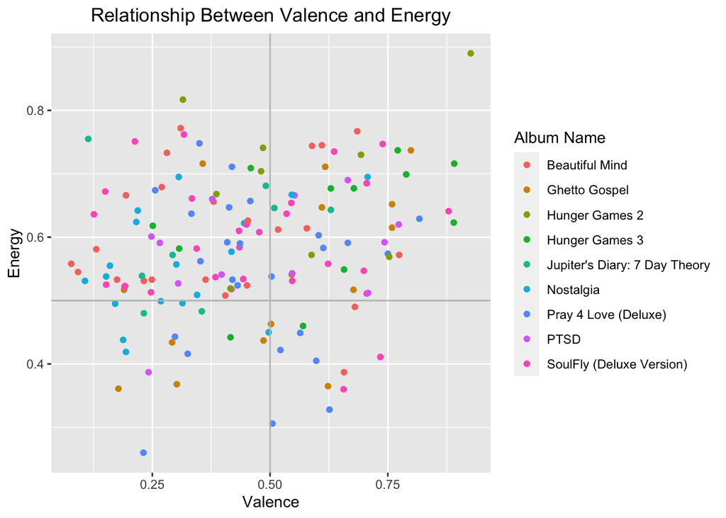

```r
ggplot(df, aes(x = valence, y = energy, color = album_name)) +
  geom_point() +
  geom_hline(yintercept = 0.5, color = "grey") +
  geom_vline(xintercept = 0.5, color = "grey") +
  labs(title = "Relationship Between Valence and Energy", x = "Valence", y = "Energy", color = "Album Name") +
   theme(plot.title = element_text(hjust = 0.5))
```

Visually, it appears that most albums are high energy and have a slightly lower valence level. Lets take a look at the most valent and energetic albums individually.

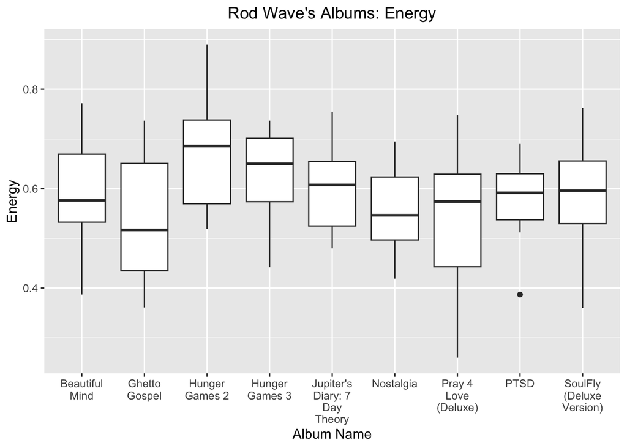

```r
df$album_name <- as.factor(df$album_name)

ggplot(df, aes(x = album_name, y = energy)) +
  geom_boxplot() +
  ggtitle("Rod Wave's Albums: Energy") +
    theme(plot.title = element_text(hjust = 0.5)) + #center title
  labs(x = "Album Name", y = "Energy") +
  scale_x_discrete(labels = function(x) lapply(strwrap(x, width = 10, simplify = FALSE), paste, collapse="\n")) #wrap lables
```

From this, we can tell that Rod Wave’s most energetic albums are **Hunger Games 2, Hunger Games 3, and Jupiter Diary: 7 Day Theory**. His least energetic album is Ghetto Gospel.

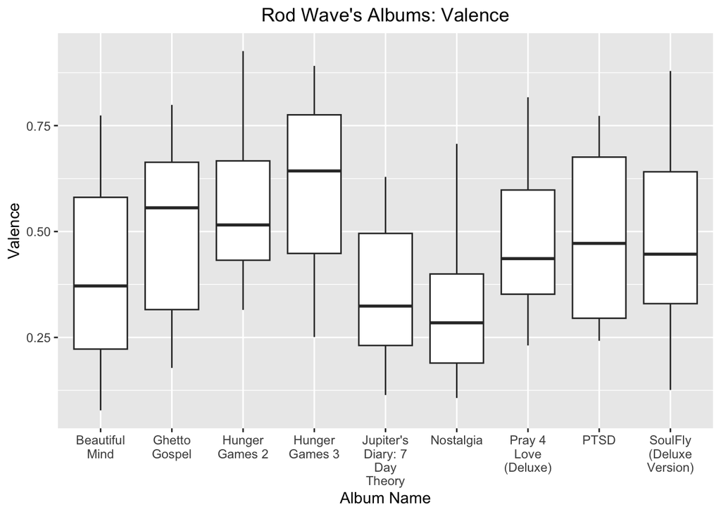

```r
df$album_name <- as.factor(df$album_name)

ggplot(df, aes(x = album_name, y = valence)) +
  geom_boxplot() +
  ggtitle("Rod Wave's Albums: Valence") +
    theme(plot.title = element_text(hjust = 0.5)) +
  labs(x = "Album Name", y = "Valence") +
  scale_x_discrete(labels = function(x) lapply(strwrap(x, width = 10, simplify = FALSE), paste, collapse="\n"))
```

Here, we can tell that Rod Wave’s albums with the lowest valence level is Nostalgia. On the other hand, the albums with the highest valence levels are **Hunger Games 3, Ghetto Gospel, and Hunger Games 2**. Lets take a look at the songs in these albums.

## Song Analysis

What are the most energetic songs by Rod Wave? Are they in the same albums that are the most energetic, **Hunger Games 2, Hunger Games 3, or Jupiter Diary: 7 Day Theory**?

```r
df |> slice_max(energy, n=5) |> dplyr::select(track_name, album_name, album_release_year, energy) |> knitr::kable(digits = 2)
```

| track_name | album_name | album_release_year | energy |
| --- | --- | --- | --- |
| I Get Around | Hunger Games 2 | 2018 | 0.89 |
| Changing On Me | Hunger Games 2 | 2018 | 0.82 |
| I Know It | Beautiful Mind | 2022 | 0.77 |
| Married Next Year | Beautiful Mind | 2022 | 0.77 |
| Time Heals | SoulFly (Deluxe Version) | 2021 | 0.76 |

Only 2 out of 5 songs are from these albums.

Which songs by Rod Wave have the highest valence levels? Are they in the same albums that have the highest valence levels, **Hunger Games 3, Ghetto Gospel, and Hunger Games 2**?

```r
df |> slice_max(valence, n=5) |> dplyr::select(track_name, album_name, album_release_year, valence) |> knitr::kable(digits = 2)
```

| track_name | album_name | album_release_year | valence |
| --- | --- | --- | --- |
| I Get Around | Hunger Games 2 | 2018 | 0.93 |
| Can’t Sleep | Hunger Games 3 | 2018 | 0.89 |
| Weight On My Shoulders | Hunger Games 3 | 2018 | 0.89 |
| Don’t Forget | SoulFly (Deluxe Version) | 2021 | 0.88 |
| Sack Right (feat. Yo Gotti) | Pray 4 Love (Deluxe) | 2020 | 0.82 |

3 out of 5 songs are from the albums that we found that the highest valence levels.

Now, I am interested to see if the tempo of Rod Wave’s songs have a relationship with its danceability.

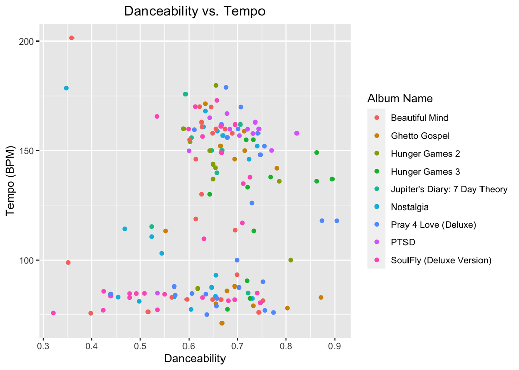

```r
ggplot(df, aes(x = danceability, y = tempo, color = album_name)) +
  geom_point() +
  labs(title = "Danceability vs. Tempo", x = "Danceability", y = "Tempo (BPM)", color = "Album Name") +
   theme(plot.title = element_text(hjust = 0.5))
```

It seems like the songs do not necessarily need to have a high tempo to be danceable, however, many do.

We have now learned a lot about Rod Wave, his albums, and his songs!

# References

https://en.wikipedia.org/wiki/Rod_Wave

https://en.wikipedia.org/wiki/Rod_Wave_discography#:~:text=The%20discography%20of%20American%20rapper,%2C%20and%20twenty%2Dfour%20singles.

https://www.youtube.com/watch?v=kC8YEw9h2-Q

https://www.youtube.com/watch?v=zVHZCe6Slnw

https://developer.spotify.com/documentation/web-api/reference/get-audio-features